# Linear Regression Model: mtcars

Timothy Chen Allen

Tuesday, June 23, 2015

# Multiple Regression using the `mtcars` built-in dataset

Multiple Regression extends the regression model beyond one explanatory variable. The purposes are still to understand relationships between variables and make predictions. Simple regression almost never is enough to understand our data; mathematically, adding more explanatory variables will make the model fit the data better. BUT…

# Watch out for Overmodeling!

We can add more and more explanatory variables, and the model will fit the training data better… but it may not work for other cases! So we try to only add variables that make sense (moon phase probably doesn’t affect wildfire occurences!) and add the least we can while still getting a good fit.

## Our Dataset: `mtcars`

`mtcars` is one of the built-in datasets in the `datasets` package of `R`. `mtcars` data was extracted from the 1974 Motor Trend US magazine, and comprises fuel consumption and 10 aspects of automobile design and performance for 32 automobiles (1973–74 models).

| element | Description |
| --- | --- |
| mpg | Miles/(US) gallon |
| cyl | Number of cylinders |
| disp | Displacement (cu.in.) |
| hp | Gross horsepower |
| drat | Rear axle ratio |
| wt | Weight (lb/1000) |
| qsec | 1/4 mile time |
| vs | V/Straight Engine (0 = V, 1 = straight) |
| am | Transmission (0 = automatic, 1 = manual) |
| gear | Number of forward gears |
| carb | Number of carburetors |

## Objective

Create a model of `mpg` taking into account other independent variables.

## Picking the variables

A big part of this is going to be selecting the right explanatory variables. This ends up being something of an art, but R facilitates it.

1. Consider that some variables in the dataset are actually dependent variables `(mpg, hp, qsec)`, so I do not consider them.

```r
mt <- mtcars[c("mpg","cyl","disp","drat","wt","vs","am","gear","carb")]
# I like seeing this in mpg order to help me start understanding
(mt <- mt[order(mt$mpg,decreasing=TRUE),])
```

```
##                      mpg cyl  disp drat    wt vs am gear carb
## Toyota Corolla      33.9   4  71.1 4.22 1.835  1  1    4    1
## Fiat 128            32.4   4  78.7 4.08 2.200  1  1    4    1
## Honda Civic         30.4   4  75.7 4.93 1.615  1  1    4    2
## Lotus Europa        30.4   4  95.1 3.77 1.513  1  1    5    2
## Fiat X1-9           27.3   4  79.0 4.08 1.935  1  1    4    1
## Porsche 914-2       26.0   4 120.3 4.43 2.140  0  1    5    2
## Merc 240D           24.4   4 146.7 3.69 3.190  1  0    4    2
## Datsun 710          22.8   4 108.0 3.85 2.320  1  1    4    1
## Merc 230            22.8   4 140.8 3.92 3.150  1  0    4    2
## Toyota Corona       21.5   4 120.1 3.70 2.465  1  0    3    1
## Hornet 4 Drive      21.4   6 258.0 3.08 3.215  1  0    3    1
## Volvo 142E          21.4   4 121.0 4.11 2.780  1  1    4    2
## Mazda RX4           21.0   6 160.0 3.90 2.620  0  1    4    4
## Mazda RX4 Wag       21.0   6 160.0 3.90 2.875  0  1    4    4
## Ferrari Dino        19.7   6 145.0 3.62 2.770  0  1    5    6
## Merc 280            19.2   6 167.6 3.92 3.440  1  0    4    4
## Pontiac Firebird    19.2   8 400.0 3.08 3.845  0  0    3    2
## Hornet Sportabout   18.7   8 360.0 3.15 3.440  0  0    3    2
## Valiant             18.1   6 225.0 2.76 3.460  1  0    3    1
## Merc 280C           17.8   6 167.6 3.92 3.440  1  0    4    4
## Merc 450SL          17.3   8 275.8 3.07 3.730  0  0    3    3
## Merc 450SE          16.4   8 275.8 3.07 4.070  0  0    3    3
## Ford Pantera L      15.8   8 351.0 4.22 3.170  0  1    5    4
## Dodge Challenger    15.5   8 318.0 2.76 3.520  0  0    3    2
## Merc 450SLC         15.2   8 275.8 3.07 3.780  0  0    3    3
## AMC Javelin         15.2   8 304.0 3.15 3.435  0  0    3    2
## Maserati Bora       15.0   8 301.0 3.54 3.570  0  1    5    8
## Chrysler Imperial   14.7   8 440.0 3.23 5.345  0  0    3    4
## Duster 360          14.3   8 360.0 3.21 3.570  0  0    3    4
## Camaro Z28          13.3   8 350.0 3.73 3.840  0  0    3    4
## Cadillac Fleetwood  10.4   8 472.0 2.93 5.250  0  0    3    4
## Lincoln Continental 10.4   8 460.0 3.00 5.424  0  0    3    4
```

2. Some variables are probably highly **correlated** (e.g. `cyl` and `disp`); we can test this using `pairs`. Let’s turn off the upper triangle, as it’s redundant.

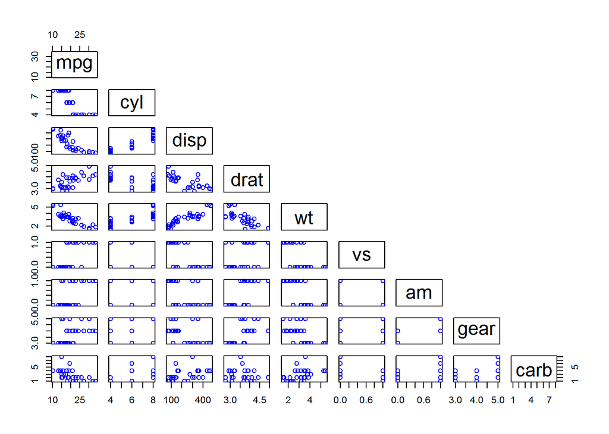

```r
pairs(x = mt, upper.panel=NULL, col="blue")
```

3. It appears that `cyl` and `disp`, and `disp` and `wt`, may be correlated. Let’s check it with the `cor` function

```r
cor(mt$cyl, mt$disp) # 0.902 - Just use one-- I like cyl
```

```
## [1] 0.9020329
```

```r
cor(mt$disp, mt$wt)  # 0.888 - Just use one-- I like wt
```

```
## [1] 0.8879799
```

```r
cor(mt$cyl, mt$wt)   # 0.782 - Use both
```

```
## [1] 0.7824958
```

## Create an initial model

Let’s create the model with the remaining variables, and evaluate the model’s *p*-value, Multiple R-squared, and coefficients’ *p*-values.

```r
m.mpg <- lm(mpg ~ cyl + drat + wt + vs + am + gear + carb, data=mtcars)
summary(m.mpg)
```

```
##
## Call:
## lm(formula = mpg ~ cyl + drat + wt + vs + am + gear + carb, data = mtcars)
##
## Residuals:
##     Min      1Q  Median      3Q     Max
## -4.4597 -1.0844 -0.1962  1.5262  5.2217
##
## Coefficients:
##             Estimate Std. Error t value Pr(>|t|)
## (Intercept)  30.1961    10.6661   2.831  0.00924 **
## cyl          -0.8425     0.7483  -1.126  0.27134
## drat          0.8302     1.6054   0.517  0.60980
## wt           -2.2915     1.0414  -2.200  0.03765 *
## vs            0.6822     1.8688   0.365  0.71826
## am            1.6458     1.9380   0.849  0.40415
## gear          0.2787     1.4371   0.194  0.84786
## carb         -0.8892     0.5696  -1.561  0.13162
## ---
## Signif. codes:  0 '***' 0.001 '**' 0.01 '*' 0.05 '.' 0.1 ' ' 1
##
## Residual standard error: 2.626 on 24 degrees of freedom
## Multiple R-squared:  0.853,  Adjusted R-squared:  0.8101
## F-statistic: 19.89 on 7 and 24 DF,  p-value: 1.489e-08
```

## Use `step` to trim down the model

Let’s use `step` to strip out less useful variables. `step` is pretty dumb; it just tries every possible model and chooses the one with the lowest AIC (*Akaike Information Criteria*). Don’t just let `step` create your model for you; you need to understand possible relationships or the model becomes meaningless. `step` also produces a lot of output if you don’t specify `trace=0`.

```r
m.mpg.step <- step(object = m.mpg, direction = "both", trace=0)
summary(m.mpg.step)
```

```
##
## Call:
## lm(formula = mpg ~ cyl + wt + carb, data = mtcars)
##
## Residuals:
##     Min      1Q  Median      3Q     Max
## -4.6692 -1.5668 -0.4254  1.2567  5.7404
##
## Coefficients:
##             Estimate Std. Error t value Pr(>|t|)
## (Intercept)  39.6021     1.6823  23.541  < 2e-16 ***
## cyl          -1.2898     0.4326  -2.981 0.005880 **
## wt           -3.1595     0.7423  -4.256 0.000211 ***
## carb         -0.4858     0.3295  -1.474 0.151536
## ---
## Signif. codes:  0 '***' 0.001 '**' 0.01 '*' 0.05 '.' 0.1 ' ' 1
##
## Residual standard error: 2.517 on 28 degrees of freedom
## Multiple R-squared:  0.8425, Adjusted R-squared:  0.8256
## F-statistic: 49.91 on 3 and 28 DF,  p-value: 2.322e-11
```

although `carb` appears, its coefficient is not significant. build a model without it:

```r
m.mpg2 <- lm(mpg ~ cyl + wt, data=mtcars)
summary(m.mpg2)
```

```
##
## Call:
## lm(formula = mpg ~ cyl + wt, data = mtcars)
##
## Residuals:
##     Min      1Q  Median      3Q     Max
## -4.2893 -1.5512 -0.4684  1.5743  6.1004
##
## Coefficients:
##             Estimate Std. Error t value Pr(>|t|)
## (Intercept)  39.6863     1.7150  23.141  < 2e-16 ***
## cyl          -1.5078     0.4147  -3.636 0.001064 **
## wt           -3.1910     0.7569  -4.216 0.000222 ***
## ---
## Signif. codes:  0 '***' 0.001 '**' 0.01 '*' 0.05 '.' 0.1 ' ' 1
##
## Residual standard error: 2.568 on 29 degrees of freedom
## Multiple R-squared:  0.8302, Adjusted R-squared:  0.8185
## F-statistic: 70.91 on 2 and 29 DF,  p-value: 6.809e-12
```

## Tweak the model: interaction effects

I want to try out a single interaction effect; this means that I believe there is a possibility that the combination of less cylinders and a manual transmission may improve mileage more than those factors by themselves.

This points out an unfortunate fact: it is easier to build a model if you have some understanding of the subject matter.

```r
m.mpg3 <- lm(mpg ~ cyl * am + wt, data=mtcars)
summary(m.mpg3)
```

```
##
## Call:
## lm(formula = mpg ~ cyl * am + wt, data = mtcars)
##
## Residuals:
##     Min      1Q  Median      3Q     Max
## -4.3002 -1.3873 -0.2748  1.1857  5.3250
##
## Coefficients:
##             Estimate Std. Error t value Pr(>|t|)
## (Intercept)  35.9179     3.0485  11.782 3.77e-12 ***
## cyl          -1.0515     0.4608  -2.282  0.03058 *
## am            7.2667     3.7242   1.951  0.06148 .
## wt           -3.0420     0.8656  -3.514  0.00157 **
## cyl:am       -1.2053     0.5971  -2.019  0.05356 .
## ---
## Signif. codes:  0 '***' 0.001 '**' 0.01 '*' 0.05 '.' 0.1 ' ' 1
##
## Residual standard error: 2.48 on 27 degrees of freedom
## Multiple R-squared:  0.8526, Adjusted R-squared:  0.8307
## F-statistic: 39.04 on 4 and 27 DF,  p-value: 7.456e-11
```

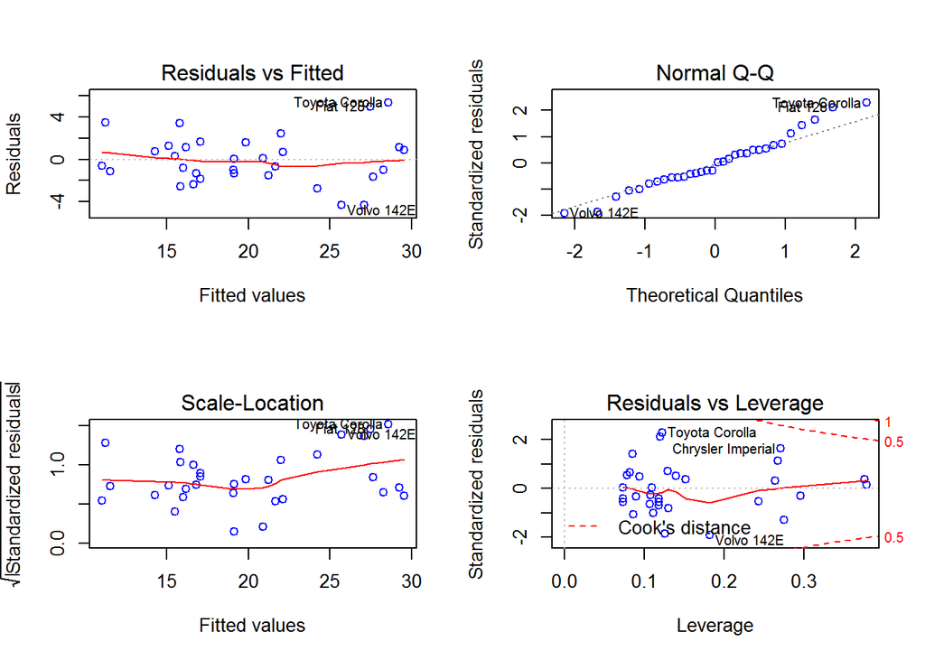

```r
par(mfrow=c(2,2))
plot(m.mpg3, col="blue")
```

## Compare models with the AIC

The **Akaike Information Criteria** is a way of comparing models. It rewards better fit, but penalizes additional explanatory variables (thus avoiding *overmodeling*):

```r
AIC(m.mpg)
```

```
## [1] 161.4044
```

```r
AIC(m.mpg.step)
```

```
## [1] 155.6175
```

```r
AIC(m.mpg2)
```

```
## [1] 156.0101
```

```r
AIC(m.mpg3)
```

```
## [1] 155.4911
```

## Pick a model

```r
m.mpg3
```

```
##
## Call:
## lm(formula = mpg ~ cyl * am + wt, data = mtcars)
##
## Coefficients:
## (Intercept)          cyl           am           wt       cyl:am
##      35.918       -1.052        7.267       -3.042       -1.205
```

## Use the model to predict

The 2015 Kia Soul with a manual transmission gets 26 mpg. The model predicts 25.94; pretty good.

```r
kia.soul <- data.frame(mpg=26, cyl=4, am=1, wt=2.7)
row.names(kia.soul) <- "Kia Soul 2015"
predict(m.mpg3, newdata=kia.soul)
```

```
## Kia Soul 2015
##      25.94361
```